# Ökonomische Analyse der deutschen Land- und Forstwirtschaft

Subventionen, Klimarisiken und ihre Folgen

# Motivation

Die Land- und Forstwirtschaft prägt nicht nur unsere Kulturlandschaft, sondern ist auch ein fundamentaler Pfeiler unserer Volkswirtschaft. Sie sichert unsere Ernährung und versorgt uns mit wichtigen Rohstoffen. Doch dieser Sektor steht heute im Spannungsfeld zweier großer Herausforderungen: Einerseits milliardenschwere staatliche Subventionen, die Stabilität und Wettbewerbsfähigkeit sichern sollen, und andererseits steigende Produktionskosten, volatile Märkte und strukturelle Anpassungszwänge, die die wirtschaftliche Tragfähigkeit vieler Betriebe gefährden.

# Datengrundlage

In diesem Projekt werden Sie anhand von aktuellen Daten des Bundesministeriums, der EU-Kommission (GAP-Zahlungen) und statistischer Ämter die ökonomischen Dimensionen dieser Entwicklungen genau untersuchen. Sie werden analysieren, wie Subventionen verteilt werden, welche Betriebstypen und Regionen besonders abhängig von Förderungen sind und welche wirtschaftlichen Effekte daraus entstehen. Der Fokus liegt dabei sowohl auf der gesamtwirtschaftlichen Perspektive als auch auf spezifischen Teilsektoren - etwa der Forstwirtschaft als Fallstudie für strukturelle Transformation und Kostenentwicklung.

Ihre Aufgabe ist es, durch fundierte datengestützte Analysen Licht ins Dunkel dieser komplexen Zusammenhänge zu bringen. Sie werden die Effektivität von Förderinstrumenten kritisch hinterfragen, Verteilungswirkungen quantifizieren und die realen volkswirtschaftlichen Kosten des aktuellen Subventionssystems bewerten. Auf Basis Ihrer Erkenntnisse können Sie fundierte Handlungsempfehlungen ableiten, die für Politik, Agrarverbände und Unternehmen von entscheidender Bedeutung sind, um die deutsche Land- und Forstwirtschaft effizienter, wettbewerbsfähiger und wirtschaftlich zukunftsfähig zu gestalten.

1. Verschaffen Sie sich in einem ersten Schritt einen Überblick über die gesamtwirtschaftliche Bedeutung der Land- und Forstwirtschaft. Dies hilft Ihnen, die Relevanz der staatlichen Förderungen und die potenziellen Kosten besser einzuordnen. Führen Sie eine Recherche durch, um die folgenden makroökonomischen Kennzahlen für das Jahr 2024 zu ermitteln. Beantworten Sie die folgenden Fragen in Textform und geben Sie für jede Information die exakte Quelle an.
- EU-Agrarsubventionen:
  - Wie hoch ist das Gesamtbudget für die Gemeinsame Agrarpolitik (GAP) der EU für Gesamteuropa?
  - Welchen Betrag davon erhält Deutschland?
- Wirtschaftliche Bedeutung (Bruttoinlandsprodukt - BIP):
  - Wie hoch ist der prozentuale Anteil der Land- und Forstwirtschaft am BIP der gesamten EU?
  - Wie hoch ist der entsprechende Anteil am BIP Deutschlands?
- Bedeutung für den Arbeitsmarkt:
  - Welcher prozentuale Anteil aller Erwerbstätigen in der EU ist im Sektor Land- und Forstwirtschaft beschäftigt?
  - Welcher prozentuale Anteil ist es in Deutschland?
- EU-Agrarsubventionen: Das Gesamtbudget der Gemeinsame Agrarpolitik (GAP) der Europäische Union für den Zeitraum 2021–2027 beträgt 386,6 Milliarden Euro. Quelle: Europäisches Parlament Der Anteil für Deutschland liegt bei etwa 11,2 % der EU-Mittel. Quelle: Europäisches Parlament
- Wirtschaftliche Bedeutung (BIP): Der Anteil der Land- und Forstwirtschaft am BIP der EU beträgt rund 1,3 %. Quelle: European Commission In Deutschland liegt der Anteil der Land- und Forstwirtschaft am BIP bei ca. 0,83 % (Wert 2024). Quelle: TheGlobalEconomy.com
- Bedeutung für den Arbeitsmarkt: Im EU-Durchschnitt sind etwa 3,5 % der Erwerbstätigen im Bereich Landwirtschaft, Forstwirtschaft und Fischerei beschäftigt. Quelle: OECD
- Für Deutschland lässt sich kein aktueller exakter Prozentwert mit verlässlicher Quelle finden — dafür sind Daten häufig älter.

## Einlesen

Für die Politik und die Wirtschaft ist es von entscheidender Bedeutung zu verstehen, wie sich der strukturelle Wandel, bestehend aus steigenden Produktionskosten, globalen Handelskonflikten, technologischem Wandel und veränderten Marktbedingungen, auf die Erträge, Kosten und die Struktur des gesamten Sektors auswirkt. Um diese komplexen Zusammenhänge zu beleuchten, sollen Sie nun die nachfolgenden Datensätze und Berichte genauer analysieren.

2. Lesen Sie den Datensatz `Subventionen.csv` aus ihrem `Daten`-Ordner ein und speichern Sie diesen als `subventionen_gesamt` ab.

Der Datensatz enthält für jeden Begünstigten (z.B. einen Landwirt oder ein Unternehmen) oft mehrere Beobachtungen in unterschiedlichen Zeilen. Dies liegt daran, dass für jede erhaltene Fördermaßnahme eine eigene Zeile existiert. Der Datensatz ist aktuell nicht für eine Analyse auf Ebene des Begünstigten passend, da die Informationen zu den verschiedenen Fördertöpfen untereinander stehen, weshalb der Datensatz nun in ein Wide-Format umgewandelt werden soll. Passen Sie den Datensatz so an, dass die unterschiedlichen Fördertöpfe (EGFL, ELER, Nationale_Kofinanzierung) die Spalten darstellen. Tragen Sie in die Zellen die jeweiligen Gesamtbeträge ein, die ein Begünstigter aus dem entsprechenden Topf im jeweiligen Jahr erhalten hat.

Erstellen Sie anschließend eine neue Spalte namens `Förderbetrag_berechnet`. Diese Spalte soll für jeden Begünstigten die Summe aus den Werten der Spalten `EGFL_Förderbetrag`, `ELER_Förderbetrag` und `Nationale_Kofinanzierung` enthalten.

Recherchieren Sie die Bedeutung der drei Hauptfördertöpfe EGFL, ELER und Nationale Kofinanzierung. Erklären Sie anschließend kurz in Ihren eigenen Worten, wofür diese Fonds stehen und wie sie sich in ihren Förderzielen und Maßnahmen unterscheiden.

*Hinweis 1:* Die Datei `Subventionen.csv.zip` enthält die `Subventionen.csv` in gezippter Form um diese in GitHub hochladen zu können. Sie können die entzippte Datei nicht auf GitHub pushen, sondern immer nur `Subventionen.csv.zip`.

*Hinweis 2:* Für die Recherche können die Seiten des [Bundesministeriums für Landwirtschaft, Ernährung und Heimat (BMLEH)](https://www.bmleh.de/DE/Home/home_node.html) oder der [EU-Kommission](https://commission.europa.eu/index_de) hilfreich sein.

*Hinweis 3:* Die Daten haben wir für Sie entsprechend aufbereitet. Die Ursprungsdaten können Sie auf [der folgenden Webseite](https://www.agrarzahlungen.de/agrarfonds/bs) finden.

- EGFL (Europäischer Garantiefonds für die Landwirtschaft): EGFL ist der „Haupt-Geldtopf“ der 1. Säule der GAP. Er bezahlt vor allem Direktzahlungen an Landwirte (Einkommensstützung pro Hektar) und Marktmaßnahmen, z.B. wenn Preise einbrechen oder der Markt stabilisiert werden soll.
- ELER (Europäischer Landwirtschaftsfonds für die Entwicklung des ländlichen Raums): ELER gehört zur 2. Säule der GAP. Er fördert die Entwicklung des ländlichen Raums: z.B. Umwelt- und klimafreundliche Bewirtschaftung, Ökolandbau, Tier- und Naturschutz, Diversifizierung (z.B. Urlaub auf dem Bauernhof), Infrastruktur und Lebensqualität in Dörfern.
- Nationale Kofinanzierung: Viele ELER-Programme werden nicht nur aus EU-Geld bezahlt, sondern zusätzlich aus nationalen oder regionalen Haushalten mitfinanziert – das nennt man nationale Kofinanzierung. Sie heißt so, weil EU und Mitgliedstaat sich die Kosten teilen: ein Teil kommt aus ELER, der andere Teil aus Bundes- oder Landesmitteln.

Nachdem Sie die Daten zu den Subventionen aufbereitet haben, wenden Sie sich nun den zentralen Daten der Waldbrandstatistiken zu. Um später die ökonomischen Folgen von Produktionsrisiken und strukturellen Belastungen analysieren zu können, ist es wichtig, auch diese Daten vorab aufzubereiten und in ein wide Format zu bringen, welches für die Folgeanalysen erforderlich ist.

3. Lesen Sie den Datensatz `Waldbrände_gesamt.csv` ein und speichern diesen als `waldbraende_gesamt` ab. In diesem Datensatz erhalten Sie eine Übersicht, wie viele Waldbrände monatlich in einem Bundesland (und in Deutschland gesamt) auftreten und welche Fläche dabei gebrannt hat. Der Datensatz liegt aktuell noch im long-Format vor. Transformieren Sie den Datensatz so, dass Sie pro Region und Monat eine Beobachtung haben. Erstellen Sie dabei separate Spalten für die `Anzahl` der Brände und die verbrannte `Fläche` (in Hektar). Benennen Sie abschließend die Spalten für die Gesamtbrände in `Gesamtmonatlich_Anzahl` und `Gesamtmonatlich_ha` um.

*Hinweis:* Auch für diese Aufgabe haben wir die Daten für Sie aufbereitet. Die Originaldaten können Sie auf [der folgenden Webseite](https://open-data.ble.de/dataset/waldbrandstatistik-fur-deutschland) finden.

4. In einem weiteren Datensatz haben Sie nun aggregierte Jahreswerte zu Ursachen, Kosten und Präventionsmaßnahmen von Waldbränden auf Bundeslandebene (einschließlich Gesamtdeutschland). Lesen Sie hierzu den Datensatz `Waldbrände_Übersicht.csv` ein und speichern diesen als `waldbraende_information` ab. Fügen Sie anschließend die beiden Datensätze `waldbraende_gesamt` und `waldbraende_information` zu einem großen Datensatz `waldbraende` zusammen. Verwenden Sie die Variablen `Region` und `Jahr` als Schlüssel für ihren `Join`.

Beantworten Sie anschließend die Frage, welche Art von “Join” sich in diesem Fall anbietet und warum?

*Hinweis:* Der Datensatz `waldbraende` ist nun ihr Hauptdatensatz, der als Grundlage für die Analysen zu Waldbränden und deren Faktoren dient.

- Für das Zusammenführen der beiden Datensätze verwende ich einen Left Join, weil waldbraende_gesamt mein Hauptdatensatz ist. Er enthält die monatlichen Waldbrandzahlen, die ich auf keinen Fall verlieren darf.
- Der zweite Datensatz waldbraende_information liefert dazu passende Jahresinformationen pro Bundesland. Diese sollen lediglich ergänzt werden.
- Mit einem Left Join bleiben alle Monate und Regionen aus dem Hauptdatensatz vollständig erhalten, und die passenden Jahreswerte werden nur dort angefügt, wo sie vorhanden sind. Damit gehen keine wichtigen Beobachtungen verloren, und die Daten bleiben vollständig auswertbar.

## Konsistenzcheck

Nachdem Sie im ersten Teil die Rohdaten aufbereitet haben, folgt nun die Validierung und erste deskriptive Analysen. In einem primären Schritt ist es das Ziel, die Struktur der Fördergelder zu verstehen, Ungereimtheiten in den Daten aufzudecken und erste ökonomische Muster im Kontext der Landwirtschaft zu erkennen.

5. In Ihrem aufbereiteten Datensatz `subventionen_gesamt` haben Sie nun eine Spalte mit dem angegebenen Gesamtbetrag (Förderbetrag_gesamt) pro Begünstigtem und eine Spalte mit Ihrer eigenen Berechnung (Förderbetrag_berechnet). Sie möchten nun überprüfen, ob Ihre eigene Summierung der Einzelbeträge mit den ausgewiesenen Gesamtsummen übereinstimmt.

Aggregieren Sie dafür Ihre Daten auf Ebene der Bundesländer unabhängig der einzelnen Jahre 2023 und 2024. Erstellen Sie eine übersichtliche Tabelle, die für jedes Bundesland die folgenden Spalten enthält:

- Die Summe der in den Originaldaten ausgewiesenen Gesamtbeträge pro Begünstigten (Förderbetrag_gesamt).
- Die Summe aus den beiden zuvor berechneten Spalten (Förderbetrag_berechnet).
- Die absolute Abweichung zwischen diesen Förderbeträgen.

Achten Sie dabei auf eine ansprechende Darstellung mithilfe der Pakete kableExtra oder gt. Sortieren Sie die Tabelle absteigend nach der Summe laut Originaldaten. Beschreiben und interpretieren Sie ihre Tabelle. Gehen Sie bei der Interpretation insbesondere auf folgende Fragen ein:

- In welchen Bundesländern ist die absolute Summe der “unerklärten” Differenzen am größten?
- Sofern es zu Differenzen kommt, erklären Sie, warum es überhaupt dazu kommt, obwohl die Daten aus einer offiziellen Quelle stammen.
- Wodurch können die Unterschiede begründet sein?

*Hinweis* Für die Recherche und Beantwortung der Unterschiede können Sie folgenden Seiten als Augangslage nutzen: [European Council](https://www.consilium.europa.eu/en/policies/the-common-agricultural-policy-explained/) und [European Commission](https://agriculture.ec.europa.eu/common-agricultural-policy/financing-cap/cap-funds_en?)

| Förderbeträge Bundesland | Förderbeträge Original (Mio. €) | Förderbeträge Berechnet (Mio. €) | Förderbeträge Abweichung (Mio. €) |
| --- | --- | --- | --- |
| Bayern | 1.421 | 1.287 | 134,42 |
| Niedersachsen | 966 | 939 | 26,76 |
| Baden-Württemberg | 683 | 614 | 69,57 |
| Nordrhein-Westfalen | 634 | 594 | 39,71 |
| Sachsen-Anhalt | 599 | 553 | 46,14 |
| Mecklenburg-Vorpommern | 599 | 570 | 28,54 |
| Brandenburg | 598 | 564 | 33,99 |
| Sachsen | 476 | 446 | 29,62 |
| Thüringen | 426 | 393 | 32,74 |
| Schleswig-Holstein | 400 | 370 | 29,34 |
| Hessen | 335 | 320 | 14,59 |
| Rheinland-Pfalz | 323 | 293 | 30,21 |
| Saarland | 35 | 31 | 3,50 |
| Hamburg | 7 | 7 | 0,17 |
| Berlin | 6 | 5 | 0,87 |
| Bremen | 5 | 4 | 0,47 |

- Die größte absolute Summe der “unerklärten” Differenzen tritt in Bayern auf, gefolgt von Baden-Württemberg und Sachsen-Anhalt.
- Die Verwaltung der CAP-Mittel erfolgt durch nationale Zahlstellen (“paying agencies”), die Zahlungen buchen, korrigieren und gegenüber der EU-Kommission abrechnen. Dabei können nachträgliche Korrekturen und Umbuchungen entstehen, die sich in Detaildaten und veröffentlichten Summen leicht unterscheiden können.
- Der Grund könnte sein, dass die CAP mit mehrjährigen Zeiträumen und Übergangsregelungen (z.B. CAP 2021-27) arbeitet. Zahlungen könnten in einem anderen Haushaltsjahr oder Planungszeitraum verbucht sein als in unserer Stichprobe.

# Deskriptive Analysen - Landwirtschaft im Spannungsfeld von Förderung und finanziellen Herausforderungen

6. Zu Beginn sollen Sie sich einen ersten konkreten Überblick über die Empfängerstruktur verschaffen. Es ist wichtig zu verstehen, welche Art von Akteuren sich hinter diesen Zahlen verbergen. Ihre Aufgabe ist es, eine Tabelle mit ihrem Datensatz `subventionen_gesamt` zu erstellen, die die 6 Begünstigten mit den höchsten und die 6 Begünstigten mit den niedrigsten Gesamtfördersummen (Förderbetrag_gesamt) im Haushaltsjahr 2024 zeigt.

Die Tabelle soll folgende Informationen enthalten:

- Name des Begünstigten,
- Gesamtfördersumme,
- Postleitzahl,
- Gemeinde,
- Bundesland

Beschreiben und interpretieren Sie anschließend die Tabelle. Gehen Sie dabei auf folgende Fragen ein:

- Was ist eine Beobachtung in Ihrem Datensatz `subventionen_gesamt`?
- Was fällt Ihnen beim Vergleich der Top-6- und der Niedrigste-6-Empfänger besonders auf?
- Welche Rolle spielt die Forstwirtschaft unter den Subventionsempfängern?

Top 6 und Niedrigste 6 Subventionsempfänger (Haushaltsjahr 2024)

| Subventionsempfänger Begünstigter | Subventionsempfänger Gesamtfördersumme (€) | Subventionsempfänger PLZ | Subventionsempfänger Gemeinde | Subventionsempfänger Bundesland | Subventionsempfänger Gruppe |
| --- | --- | --- | --- | --- | --- |
| Landesbetr. f.Hochwasserschutz u. Wasserwirtsch. (LHW) | 37149868.42 | 39104 | Magdeburg, Landeshauptstadt | Sachsen-Anhalt | Top 6 |
| Landesbetrieb für Küstenschutz Nationalpark u Meeresschutz | 17070234.73 | 25813 | Husum, Stadt | Schleswig-Holstein | Top 6 |
| Land Mecklenburg-Vorpommern Ministerium für | 13243166.07 | 19061 | Schwerin, Landeshauptstadt | Mecklenburg-Vorpommern | Top 6 |
| Landesamt für Umwelt (LfU) | 7892895.63 | 14476 | Potsdam, Stadt | Brandenburg | Top 6 |
| Landgard Obst + Gemüse GmbH + Co. KG | 3825087.21 | 47638 | Straelen, Stadt | Nordrhein-Westfalen | Top 6 |
| Landesforst Mecklenburg-Vorpommern | 3795238.63 | 17139 | Malchin, Stadt | Mecklenburg-Vorpommern | Top 6 |
| Kleinempfänger | 55.51 | 04886 | Arzberg | Sachsen | Niedrigste 6 |
| Kleinempfänger | 48.80 | 96482 | Ahorn | Bayern | Niedrigste 6 |
| Kleinempfänger | 36.45 | 97753 | Karlstadt, St | Bayern | Niedrigste 6 |
| Kleinempfänger | 36.43 | 29468 | Bergen an der Dumme, Flecken | Niedersachsen | Niedrigste 6 |
| Kleinempfänger | 26.45 | 02894 | Vierkirchen | Sachsen | Niedrigste 6 |
| Kleinempfänger | 25.48 | 97348 | Markt Einersheim, M | Bayern | Niedrigste 6 |

Achten Sie auch hier auf eine ansprechende Darstellung der Tabelle. Beschreiben und interpretieren Sie ihre Tabelle. Gehen Sie insbesondere auf die Verteilungen der einzelnen Variablen ein. Was fällt hier besonders auf?

| Variable | Deskriptive Statistik der Subventionsbeträge Anzahl | Deskriptive Statistik der Subventionsbeträge Mittelwert | Deskriptive Statistik der Subventionsbeträge SD | Deskriptive Statistik der Subventionsbeträge Median | Deskriptive Statistik der Subventionsbeträge Min | Deskriptive Statistik der Subventionsbeträge Max |
| --- | --- | --- | --- | --- | --- | --- |
| EGFL Förderbetrag | 288334 | 18075.44 | 51772.29 | 7256.10 | 0 | 6345377 |
| ELER Förderbetrag | 288334 | 5818.06 | 87094.53 | 560.53 | -840 | 28223329 |
| Nationale Kofinanzierung | 288334 | 357.98 | 2362.96 | 0.00 | 0 | 644951 |
| Förderbetrag gesamt | 288334 | 26057.11 | 132233.18 | 10011.80 | 0 | 37149868 |
| Förderbetrag gesamt (berechnet) | 288334 | 24251.48 | 104736.93 | 9515.18 | 0 | 28223329 |

Die bisherigen Analysen haben Ihnen einen Überblick über die Gesamtstruktur der Agrarförderung in den Jahren 2023 und 2024 verschafft. Um die regionalen Unterschiede und die Finanzierungslogik besser zu verstehen, ist es nun sinnvoll, sich zunächst intensiv mit einem einzelnen Jahr auseinanderzusetzen. Konzentrieren Sie sich daher in der folgenden Aufgabe auf das Haushaltsjahr 2023 und analysieren Sie die detaillierte Zusammensetzung der Fördergelder auf Bundeslandebene. Diese Bestandsaufnahme ermöglicht es Ihnen später, in Aufgabe 9 systematisch Veränderungen zwischen 2023 und 2024 herauszuarbeiten.

8. Schauen Sie sich in einem nächsten Schritt die Zusammensetzung der Fördergelder im Datensatz `subventionen_gesamt` auf Bundesland-Ebene für 2023 an. Visualisieren Sie, wie sich EGFL, ELER, Nationale Kofinanzierung und Sonstige Nationale Mittel (Differenz aus Förderbetrag_gesamt und Förderbetrag_berechnet) pro Bundesland anteilig zusammensetzen. Beschränken Sie für diese Analyse ihre Daten auf das Haushaltsjahr 2023. Gruppieren Sie die Daten nach Bundesland und berechnen Sie die Summen für EGFL_Förderbetrag, ELER_Förderbetrag, Nationale_Kofinanzierung und Sonstige nationale Mittel. Erstellen Sie nun ein gestapeltes (`stacked`) Balkendiagramm, das für die Bundesländer die prozentuale Zusammensetzung der Fördergelder (in Bezug auf die gesamte Fördersumme) darstellt. Die Balken sollen die Anteile von EGFL, ELER, Nationale Kofinanzierung und der von Ihnen berechneten Differenz visualisieren.

Beschreiben und interpretieren Sie anschließend ihre Grafik. Gehen Sie insbesondere auf folgende Fragen ein:

- Welche Unterschiede in der Förderstruktur fallen Ihnen zwischen den Bundesländern auf?
- Welche Gründe könnten diese Verteilungen erklären?
- Welche ökonomischen Schwerpunkte (z.B. in Bezug auf Einkommenssicherung vs. ländliche Entwicklung) lassen sich aus diesen unterschiedlichen Strukturen für die Agrarpolitik der jeweiligen Bundesländer ableiten? Beziehen Sie sich hierbei auf Ihre Ergebnisse der Aufgabe 2.

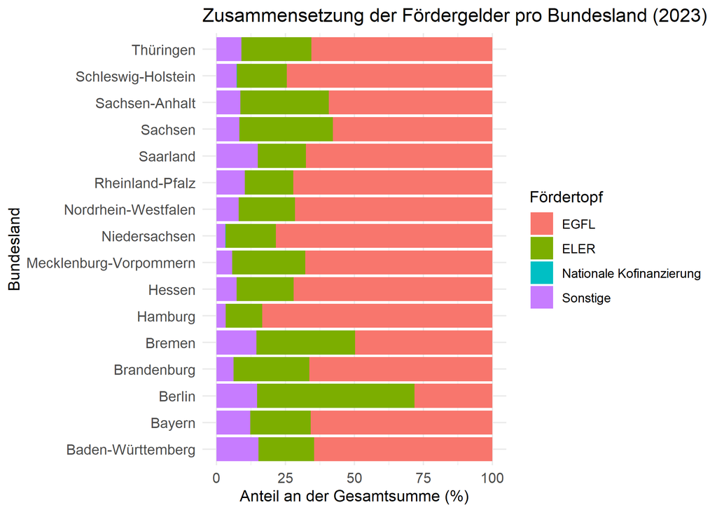

Nachdem Sie die Struktur der Förderungen innerhalb der Bundesländer und innerhalb eines Jahres analysiert haben, gehen Sie nun einen Schritt weiter und betrachten die Dynamik über die Zeit. Für politische Entscheidungsträger und Wirtschaftsanalysten ist es von großem Interesse zu sehen, ob sich das Gesamtvolumen der Agrarsubventionen verändert - und wenn ja, in welchen Regionen diese Änderungen am stärksten ausfallen. Mögliche Rückgänge oder Zuwächse können wichtige Indikatoren für politische Neuausrichtungen oder veränderte Rahmenbedingungen sein.

9. In der nächsten Aufgabe sollen Sie daher, die Entwicklung der Gesamtfördersummen zwischen 2023 und 2024 auf Bundeslandebene quantifizieren und visualisieren. Aggregieren Sie hierzu Ihren Datensatz `subventionen_gesamt` nach Bundesland und Haushaltsjahr, um die jährliche Gesamtfördersumme für jedes Bundesland zu berechnen. Berechnen Sie anschließend die absolute Veränderung der Fördersumme von 2023 auf 2024 in Millionen Euro, sowie die relative (prozentuale) Veränderung der Fördersumme im gleichen Zeitraum pro Bundesland.

Erstellen Sie eine übersichtliche Tabelle, die die Fördersummen für 2023 und 2024, sowie die absolute und relative Veränderung für alle Bundesländer darstellt. Achten Sie auf eine ansprechende und gut lesbare Formatierung mit kableExtra oder gt, inklusive sinnvoll gerundeter Zahlen.

Beschreiben und interpretieren Sie ihre Tabelle. Gehen Sie auch auf folgende Fragen ein:

- In welchen Bundesländern gab es die größten absoluten Zuwächse bzw. Rückgänge? In welchen waren die prozentualen Veränderungen am stärksten?
- Gibt es einen erkennbaren Trend über alle Bundesländer hinweg?
- Recherchieren Sie kurz mögliche Gründe für die auffälligsten Veränderungen. Welche externen Faktoren (z.B. Förderrichtlinien der EU oder nationale Umschichtungen) könnten diese Entwicklungen erklären?

*Hinweis 1:* Nutzen Sie zur Berechnung der Gesamtfördersumme die Fördermittel aus ELER, EGFL, Nationaler Kofinanzierung und sonstigen nationalen Mitteln.

*Hinweis 2:* Ordnen Sie ihre Tabelle sinnvoll an (z.B. nach den Fördersummen in 2023 oder nach den Änderungen der absoluten Fördersummen).

| Bundesland | Vergleich der Gesamtfördersummen pro Bundesland (2023 vs 2024) Summe 2023 (Mio €) | Vergleich der Gesamtfördersummen pro Bundesland (2023 vs 2024) Summe 2024 (Mio €) | Vergleich der Gesamtfördersummen pro Bundesland (2023 vs 2024) Abs. Veränderung (Mio €) | Vergleich der Gesamtfördersummen pro Bundesland (2023 vs 2024) Rel. Veränderung (%) |
| --- | --- | --- | --- | --- |
| Saarland | 17.38 | 17.33 | -0.05 | -0.3 |
| Bremen | 2.61 | 2.26 | -0.35 | -13.4 |
| Hamburg | 3.96 | 3.44 | -0.52 | -13.1 |
| Berlin | 3.76 | 2.59 | -1.18 | -31.3 |
| Hessen | 181.51 | 153.49 | -28.02 | -15.4 |
| Thüringen | 227.59 | 198.09 | -29.50 | -13.0 |
| Rheinland-Pfalz | 186.46 | 137.01 | -49.45 | -26.5 |
| Baden-Württemberg | 368.65 | 314.74 | -53.91 | -14.6 |
| Schleswig-Holstein | 227.04 | 172.53 | -54.51 | -24.0 |
| Nordrhein-Westfalen | 356.61 | 277.23 | -79.38 | -22.3 |
| Sachsen | 280.39 | 195.56 | -84.83 | -30.3 |
| Brandenburg | 343.29 | 255.08 | -88.21 | -25.7 |
| Mecklenburg-Vorpommern | 344.70 | 253.81 | -90.89 | -26.4 |
| Sachsen-Anhalt | 351.54 | 247.24 | -104.30 | -29.7 |
| Niedersachsen | 577.14 | 388.89 | -188.25 | -32.6 |
| Bayern | 814.11 | 607.12 | -206.99 | -25.4 |

Nachdem Sie die Verteilung und Entwicklung der Agrarförderungen analysiert haben, sollen Sie diese nun in den breiteren ökonomischen Kontext einbetten. Staatliche Subventionen sichern Einkommen und stabilisieren Betriebe, stehen jedoch einer Reihe von ökonomischen Risiken und Kostenfaktoren gegenüber - etwa volatile Marktpreise, steigende Produktionskosten oder strukturelle Anpassungslasten. Diese Aufgabe soll die Brücke schlagen zwischen der reinen Subventionsanalyse und der nachfolgenden, vertieften Untersuchung von wirtschaftlichen Belastungen und Risikofaktoren im Sektor.

10. Lesen Sie den Artikel [Landwirte haben Riesenschäden durch extreme Wettereignisse](https://www.wochenblatt-dlv.de/politik/landwirte-haben-riesenschaeden-extreme-wettereignisse-569840) aus dem Wochenblatt für Landwirtschaft & Landleben. Stellen Sie in einer ersten Beschreibung die im Artikel genannten jährlichen Durchschnittsschadenssummen durch Extremwetterereignisse den berechneten Subventionen ihrer Analyse gegenüber. Beantworten Sie auf Basis Ihrer bisherigen Analyse und den Erkenntnissen aus dem Artikel die folgenden Fragen:
- Diskutieren Sie das Verhältnis der Subventionen und den Schadenssummen. Inwiefern können die milliardenschweren Agrarsubventionen als eine Art staatliche Risikoprämie oder Versicherung für die Landwirtschaft interpretiert werden, um klimabedingte Ertragsschwankungen abzufedern?
- Der Artikel zitiert Bundesminister, die mehr “Krisenvorsorge” und “Anpassungsmaßnahmen” fordern. Argumentieren Sie, warum eine reine Kompensation von Schäden durch Subventionen ökonomisch weniger effizient sein könnte als die Förderung von präventiven Maßnahmen.
- Bewerten Sie die folgenden zwei politischen Ansätze zur Minderung von Klimaschäden in der Landwirtschaft. Diskutieren Sie für jeden Ansatz kurz einen potenziellen Vorteil und einen Nachteil aus ökonomischer Sicht:
  - Ansatz A: Erhöhung der Direktzahlungen (EGFL) an Landwirte, um Liquidität nach Ernteausfällen sicherzustellen.
  - Ansatz B: Umschichtung von Fördergeldern hin zu Projektförderungen (ELER), die gezielt in klimaresiliente Technologien investieren (z.B. Bewässerungssysteme, trockenresistente Sorten).
1. Verhältnis zwischen Subventionen und Schadenssummen:
- Die jährlichen Agrarsubventionen liegen in DE im Milliardenbereich, genauso wie die im Artikel genannten durchschnittlichen Schadenssummen. Damit sind die Fördermittel hoch genung, um einen wesentlichen Teil dieser Risikien abzufedern.
- Subventionen könnten deshalbt eine Art “staatliche Risikoprämie” sein. Sie stabilisieren quasi das Einkommen der Betriebe über mehrere Jahre hinweg und gleichen witterungsbedingte Ertragsschwankungen teilweise aus, ohne dass jedes einzelne Schadensereignis separat versichert sein muss.
2. Warum reine Schadenskompensationen ineffizient ist?
- Werden Schäden durch Extremwetterereignisse immer wieder nur nachträglich durch Hilfsprogramme oder zusätzliche Zahlungen ausgeglichen, fehlen eindeutige Anreize für Investitionen in Anpassung und Risikominderung. Betriebe können sich auf die erwarteten Hilfen verlassen.
- Präventive Maßnahmen (wie z.B. bessere Wasserspeicherung oder Erosionsschutz) reduzieren das Schadensrisiko deutlich auf Dauer. Ökonomisch gesehen ist das oft effizienter, da ein einmaliger Investitionszuschuss langfristig viele zukünftige Schäden verhindert, während reine Kompensation immer wieder Kosten verursacht.
3. Bewertung der politischen Ansätze:
- Ansatz A -> Erhöhung der Direktzahlungen (EGFL)

-> Vorteil: Dadurch wird kurzfristig die Liquidität der Landwirte gestärkt, besonders nach Ernteausfällen.Es können laufende Kosten bedient und Insolvenzen vermieden werden.

-> Nachteil: Die Mittel fließen pauschal und sind nicht an konkrete Anpassungsmaßnahmen gebunden. Das verursacht dauerhaft hohe laufende Ausgaben für den Staat.

- Ansatz B -> Umschichtung zu ELER‑Projektförderungen für klimaresiliente Technologien

-> Vorteil: Gelder werden gezielt in Maßnahmen investiert, die Erträge und Produktionssicherheit langfristig stabilisieren z.B. Bewässerung. Dadurch können künftige Schadenskosten sinken.

-> Nachteil: Die Wirkung tritt oft verzögert, aufgrund langer Genehmigungsverfahren ein. Außerdem führen komplexe Antragsstellungen zu hohen administrativen Kosten. Dies kann insbesondere kleinere Betriebe von der Teilnahme ausschließen und die Mittelverteilung verlangsamen.

# Deskriptive Analysen - Waldbrände als ökonomisches Risiko

Wie die bisherigen Analysen gezeigt haben, fließen erhebliche Fördermittel in die Land- und Forstwirtschaft. Um die wirtschaftliche Gesamtbilanz einordnen zu können, ist es wichtig, diesen Subventionen auch tatsächlich entstehende Kosten gegenüberzustellen.

Sie konzentrieren sich nun dabei auf Waldbrände als spezifisches Teilsegment der Forstwirtschaft. Waldbrände machen zwar nur einen kleinen Teil der gesamten Schäden im Sektor aus, bieten jedoch einen entscheidenden Vorteil: Die ökonomischen Folgen sind hier besonders gut quantifizierbar. Im Gegensatz zu Ertragsausfällen der Ernte (durch Sturm oder Ernteeinbußen durch Trockenheit) lassen sich Holzverluste, Löschkosten und Wiederaufforstungsmaßnahmen präzise beziffern. Zudem ermöglichen die verfügbaren Daten eine detaillierte Analyse nach Ursachen, Flächen und regionalen Mustern.

Diese Datentransparenz macht Waldbrände zu einem passenden Fallbeispiel, um exemplarisch zu zeigen, wie sich sektorale Belastungen entwickeln, auch im Kontext von Trockenheit und Hitzeperioden, und wie sie sich zu staatlichen Förderungen verhalten. Die nachfolgende Analyse liefert somit einen ersten konkreten Eindruck von der Größenordnung spezifischer Risiken in der Forstwirtschaft.

11. Schauen Sie sich in einem ersten Schritt an, wie viele Waldbrände (Gesamt) es in Deutschland in den Jahren von 2018 bis 2024 gab. Ihre Aufgabe ist es, eine deskriptive Tabelle zu erstellen, die die wichtigsten jährlichen Kennzahlen zum Waldbrandgeschehen in Deutschland zusammenfasst.

Filtern Sie Ihren Datensatz `waldbraende` für die Region “Deutschland”. Achten Sie darauf, dass die Werte genutzt werden, welche bereits auf Jahresebene aggregiert sind. Stellen Sie in der Tabelle die jährliche Gesamtsumme der verbrannten Fläche (ha), die Anzahl der Brandfälle, die wirtschaftlichen Verluste und die entstandenen Schäden dar.

Markieren Sie in Ihrer Tabelle die Jahre, in denen die Schadenssumme 1,5 Million Euro überstiegen hat, farblich, um Extremjahre kenntlich zu machen.

Beschreiben und interpretieren Sie ihre Tabelle. Betrachten Sie dabei insbesondere folgende Fragen:

- Identifizieren Sie die Jahre mit den höchsten Schadenssummen und den größten verbrannten Flächen.
- Was könnte das über die Art der Brände (wenige große vs. viele kleine) in diesen Jahren aussagen?
- Basierend auf dieser Übersicht: Lässt sich ein klarer Trend einer Zunahme der ökonomischen Belastung durch Waldbrände in den letzten Jahren erkennen? Begründen Sie Ihre Antwort anhand der Daten.
- In welchem Verhältnis stehen die durch Waldbrände verursachten Verluste zu den jährlichen Subventionen, die Land- und Forstwirte erhalten? Was sagt das über die wirtschaftliche Tragweite solcher Ereignisse aus? Beziehen Sie sich hierbei auf ihre vorherigen Ergebnisse.

*Hinweis:* Um die Größenordnung der verbrannten Waldfläche einordnen zu können, können Sie sich auf [folgenden Artikel](https://www.ulm.de/leben-in-ulm/umwelt-energie-entsorgung/forstwirtschaft-und-wald) beziehen.

Waldbrände in Deutschland 2018–2024: Jahreskennzahlen

| Jahr | Gesamt ha | Gesamt Anzahl | Wirtschaftliche Verluste Tsd (€) | Schaden Tsd (€) |
| --- | --- | --- | --- | --- |
| 2018 * | 2349 | 1708 | 2144 | 2670 |
| 2019 * | 2711 | 1523 | 1663 | 2220 |
| 2020 * | 368 | 1360 | 1596 | 2190 |
| 2021 | 148 | 548 | 659 | 670 |
| 2022 * | 3058 | 2397 | 4851 | 5140 |
| 2023 | 1240 | 1059 | 957 | 1190 |
| 2024 | 334 | 563 | 680 | 680 |

- Die höchsten Schadenssummen treten in den Extremjahren 2018 (2670 Tsd €), 2019 (2220 Tsd €), 2020 (2190 Tsd €) und besonders 2022 (5140 Tsd €) auf. Die größten verbrannten Flächen finden sich ebenfalls klar in den Extremjahren: 2018 (2349 ha), 2019 (2711 ha) und 2022 (3058 ha). Damit sind die Jahre mit Extremmarkierung eindeutig jene mit den stärksten ökologischen und ökonomischen Auswirkungen.
- In Jahren mit großen verbrannten Flächen und gleichzeitig hohen Schadenssummen (vor allem 2018, 2019 und 2022) deutet die Kombination darauf hin, dass es wenige, aber besonders große Brände oder eine Mischung aus vielen Bränden mit einigen sehr großen Ereignissen gegeben haben dürfte. Jahre mit niedrigen Flächen und geringeren Schäden (z. B. 2021, 2023, 2024) sprechen dagegen eher für viele kleine Brände, die jeweils nur geringe Flächen betrafen und weniger wirtschaftliche Schäden verursachten.
- Ein klarer kontinuierlicher Trend einer Zunahme lässt sich anhand der Daten nicht erkennen. Die wirtschaftlichen Verluste schwanken stark: Nach hohen Schäden in den Extremjahren 2018–2020 folgt 2021 ein sehr niedriger Wert, danach ein extremer Ausreißer 2022 und anschließend wieder deutlich geringere Verluste in 2023 und 2024. Damit zeigen die Daten keinen stetigen Anstieg, sondern eher unregelmäßige Extrema, die auf außergewöhnliche Witterungsbedingungen in bestimmten Jahren zurückzuführen sind.
- Vergleicht man die jährlichen Schäden (zwischen 659 Tsd € in 2021 und 5140 Tsd € in 2022) mit den deutlich höheren jährlichen Subventionsvolumina, zeigt sich, dass die gesamtwirtschaftliche Belastung durch Waldbrände relativ gering ist. Dennoch kann der starke Ausschlag in Extremjahren – insbesondere 2022 – für einzelne Regionen oder Betriebe beträchtliche wirtschaftliche Auswirkungen haben. Die Tabelle zeigt also, dass Waldbrände zwar nicht jedes Jahr hohe Schäden verursachen, aber in Extremjahren erhebliche wirtschaftliche Risiken darstellen.

Nachdem Sie das Gesamtausmaß der Waldbrände betrachtet haben, ist es aus ökonomischer und politischer Sicht entscheidend zu wissen, welche Eigentumsformen des Waldes am stärksten betroffen sind. Dies hat direkte Auswirkungen auf die Frage, wer die wirtschaftlichen Lasten der Schäden und der Wiederaufforstung trägt; der Bund, die Länder, Kommunen oder private Eigentümer.

12. In dieser Aufgabe sollen Sie sich die zeitliche Entwicklung der Anteile der Brandflächen und der Brandanzahl der verschiedenen Waldeigentumsformen (Bundeswald, Landeswald, Körperschaftswald, Privatwald) für Gesamtdeutschland genauer anschauen. Erstellen Sie ein oder mehrere (gestapelte) Balkendiagramme, die die prozentuale Verteilung
- der verbrannten Fläche (in ha),
- und der Anzahl der Brandfälle

über die verschiedenen Jahre hinweg nach Eigentumsform darstellen.

Beschreiben und interpretieren Sie die Diagramme. Gehen Sie hierbei insbesondere auf folgende Fragen ein:

- Welche Eigentumsform ist prozentual am häufigsten von Waldbränden betroffen, sowohl in Bezug auf die Fläche als auch auf die Anzahl der Fälle? Hat sich dieser Anteil über die Jahre signifikant verändert?
- Vergleichen Sie die beiden Diagramme: Gibt es eine Eigentumsform, die tendenziell eher viele kleine Brände (hoher Anteil bei Anzahl, geringerer bei Fläche) oder wenige, aber dafür sehr große Brände (geringer Anteil bei Anzahl, höherer bei Fläche) aufweist?
- Welche ökonomischen Schlussfolgerungen lassen sich daraus ziehen? In welchen Bereichen könnten staatliche Präventions- und Unterstützungsmaßnahmen am dringendsten benötigt werden?

*Hinweis:* Achten Sie darauf, dass bei nebeneinander angeordneten Grafiken die y-Achse identisch skaliert sein sollte.

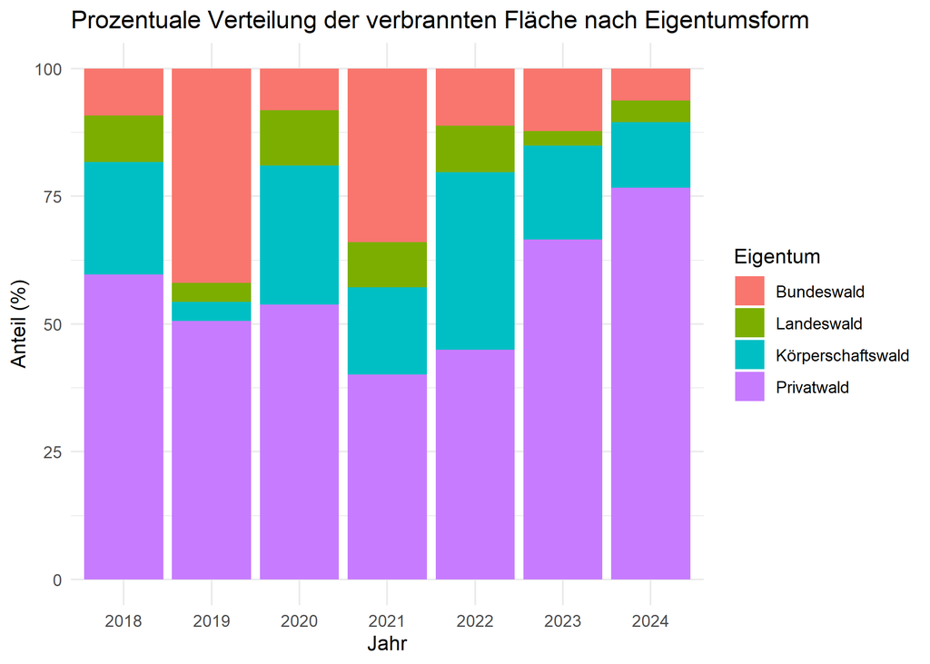

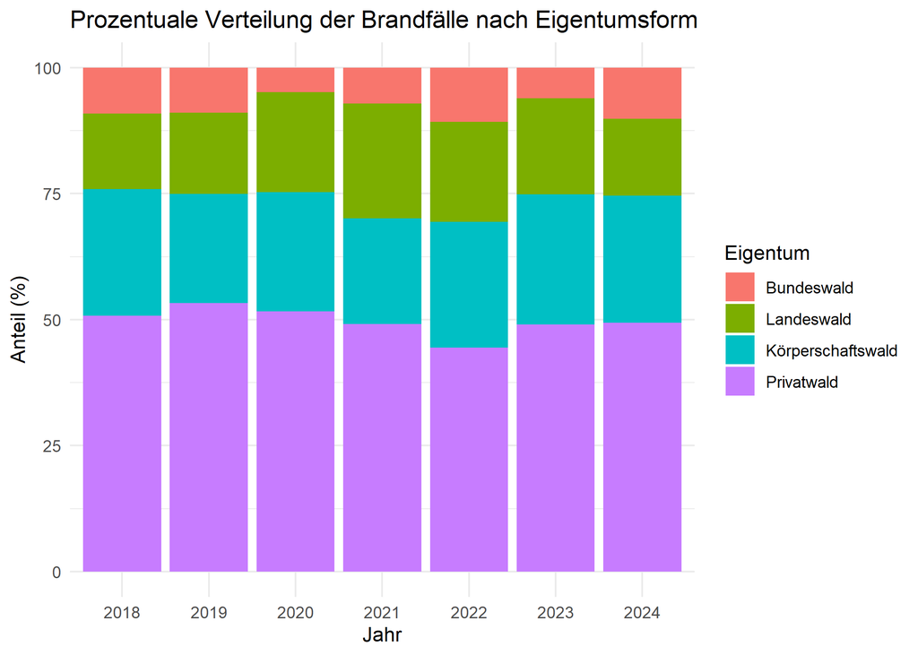

Nachdem Sie im vorherigen Schritt analysiert haben, welche Eigentumsformen besonders stark von Waldbränden betroffen sind, stellt sich nun die nächste zentrale Frage: Wie entstehen diese Brände überhaupt?

Um gezielte und wirksame Präventions- und Schutzmaßnahmen zu entwickeln, ist es wichtig, die Hintergründe und Auslöser von Waldbränden genauer zu verstehen und ihre Veränderung im Zeitverlauf nachzuvollziehen. Eine differenzierte Betrachtung der Ursachen ermöglicht es, Verantwortlichkeiten und Handlungsspielräume besser einzuordnen und künftige Risiken gezielter zu minimieren.

13. Sie sollen die Entwicklung der Waldbrände nach ihren Hauptursachen für Gesamtdeutschland analysieren. Ihr Ziel ist es, herauszuarbeiten, welche Ursachen über die Jahre hinweg die meisten Brände und die größten Flächenverluste verursacht haben. Nutzen Sie wiederum ihren Datensatz `waldbraende` und gehen Sie insbesondere auf folgende Ursachen in ihrer Analyse ein:
- Fahrlässigkeit,
- Vorsatz (Brandstiftung),
- Sonstige handlungsbedingte Einwirkungen,
- Natürliche Ursachen,
- Unbekannte Ursachen

Erstellen Sie zwei Liniendiagramme, die untereinander angeordnet sind. Das erste Diagramm zeigt die zeitliche Entwicklung der Anzahl der Waldbrände nach Ursache. Das zweite Diagramm soll die zeitliche Entwicklung der verbrannten Waldfläche (in ha) nach Ursache darlegen.

Beschreiben und interpretieren Sie die Diagramme. Gehen Sie hierbei insbesondere auf folgende Fragen ein:

- Welche Brandursache dominiert in den meisten Jahren, sowohl bei der Anzahl als auch bei der Fläche? Gibt es Jahre, in denen sich dieses Muster deutlich ändert?
- Betrachten Sie die Entwicklung über die Zeit. Erkennen Sie einen Trend bei bestimmten Ursachen (z.B. eine Zunahme natürlicher Brände in jüngerer Zeit)?
- Welche ökonomischen und politischen Implikationen hätte ein solcher Trend?

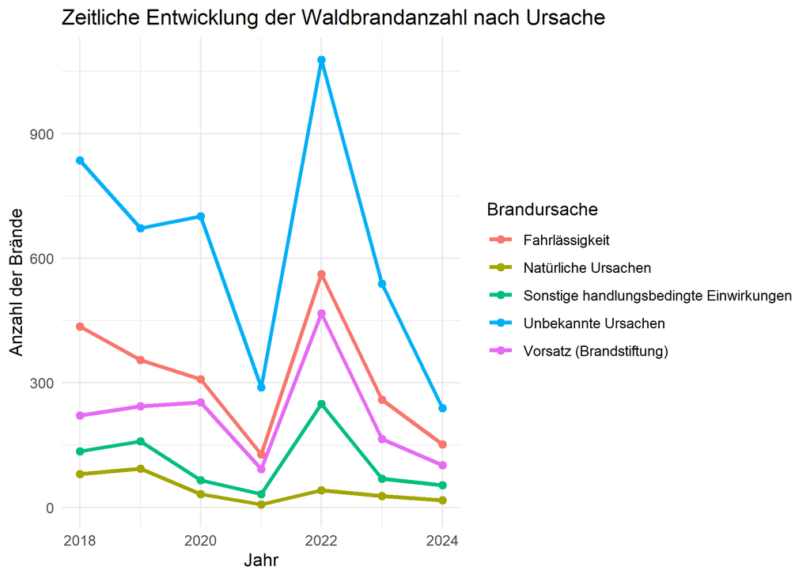

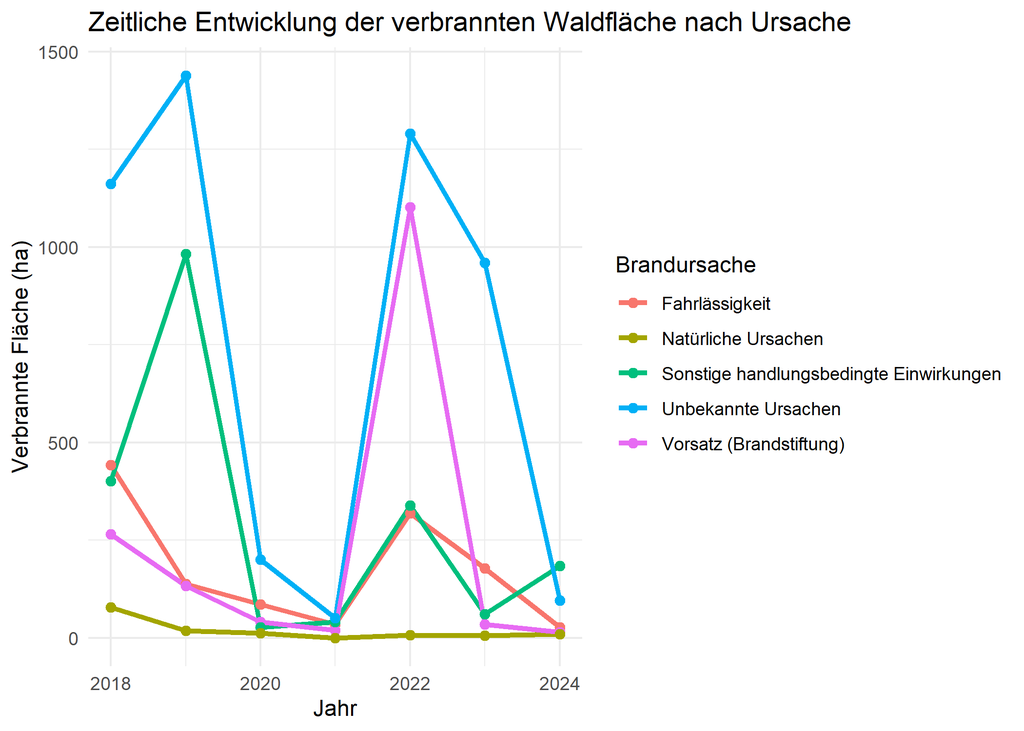

- In den meisten Jahren liegen die Werte für „Unbekannte Ursachen“ sowohl bei der Brandanzahl als auch bei der verbrannten Fläche deutlich über allen anderen Ursachen, mit besonders starken Ausschlägen im Jahr 2022. Das deutet darauf hin, dass ein großer Teil der Brände nicht eindeutig zugeordnet wird, was erhebliche Informationslücken erzeugt und die Ableitung gezielter Präventionsmaßnahmen erschwert.
- Über den gesamten Zeitraum zeigen die meisten Ursachen stark schwankende Verläufe, ohne klare langfristige Zunahmen oder Abnahmen, während natürliche Ursachen konstant auf einem sehr niedrigen Niveau bleiben. Dies spricht gegen einen stabilen Trend und dafür, dass einzelne Extremjahre oder besondere Bedingungen das Brandgeschehen stärker prägen als langfristige strukturelle Veränderungen.
- Die größten Schäden entstehen durch Brände mit unklarer Ursache, was eine zielgerichtete Risikosteuerung erschwert und zu hohen wirtschaftlichen Unsicherheiten führt. Daraus ergibt sich politisch ein Bedarf nach besseren Erfassungssystemen, Monitoring und Ursachenforschung, um Prävention und Ressourcenverteilung wirksamer gestalten zu können.

Aus wirtschaftlicher Sicht ist eine wichtige Frage, wie hoch zum einen die Schäden sind und zum anderen wie sie sich effizient verhindern lassen. Eine konkrete Stellschraube hierfür sind die laufenden Ausgaben für die Forstverwaltung und Kontrolle, die unter anderem Kosten für Präventionsmaßnahmen wie Waldpflege, Brandschutzstreifen und Überwachungssysteme umfassen.

14. In dieser Aufgabe untersuchen Sie daher den ökonomischen Zusammenhang: Stehen höhere Ausgaben für Prävention und Kontrolle in einem messbaren Verhältnis zu geringeren Schäden? Sie werden analysieren, ob Bundesländer, die mehr in ihre Forstverwaltung investieren, tendenziell niedrigere Brandkosten und -verluste aufweisen.

Erstellen Sie 2 Punktediagramme in denen Sie für jedes Bundesland und für jedes Jahr in ihrem Datensatz die

- Forstverwaltungskosten (in Tsd. Euro),
- die Sonstigen Kontrollkosten (in Tsd. Euro),

auf der x-Achse abtragen und auf der y-Achse jeweils die logarithmierten wirtschaftlichen Verluste darlegen. Verwenden Sie hier nun alle Bundesländer (ohne die Gesamtwerte für Deutschland) im Datensatz, um ein Gesamtbild zu erhalten und ordnen Sie die 2 Diagramme so an, dass ein Vergleich zwischen den Schaubildern schnell und einfach möglich ist. Beschreiben und interpretieren Sie die Diagramme. Gehen Sie hierbei insbesondere auf folgende Fragen ein:

- Welche Zusammenhänge erkennen Sie zwischen den Ausgaben für Forstverwaltung bzw. Kontrollmaßnahmen und den wirtschaftlichen Verlusten?
- Stützen die Grafiken auf den ersten Blick die Hypothese, dass höhere Präventionsausgaben mit geringeren Schäden einhergehen?
- Warum ist die Verwendung einer logarithmischen Skala für die wirtschaftlichen Verluste methodisch sinnvoll?
- Vergleichen Sie die jährlichen Präventionskosten pro Bundesland mit den wirtschaftlichen Gesamtverlusten in Deutschland aus Aufgabe 11. Was fällt Ihnen auf, wenn die Kosten einzelner Bundesländer über die Jahre hinweg teilweise ähnlich hoch sind wie die gesamten wirtschaftlichen Verluste?
- Diskutieren Sie, welche Ursachen dafür verantwortlich sein könnten, dass trotz hoher Präventions- und Kontrollkosten die Schäden nicht proportional reduziert werden. Welche Rückschlüsse lassen sich daraus für die Effizienz der Maßnahmen ziehen?

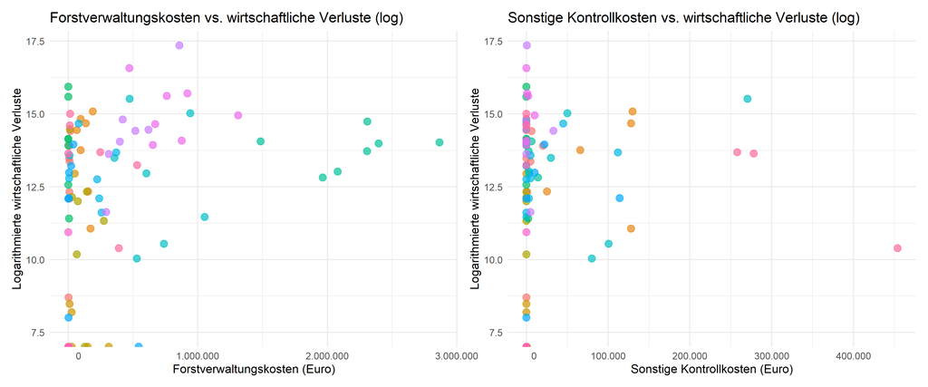

- Die Punktwolken zeigen keinen klaren Trend zwischen den Ausgaben für Forstverwaltung bzw. Kontrollkosten und den wirtschaftlichen Verlusten. Die Werte streuen stark, wodurch deutlich wird, dass höhere Ausgaben nicht automatisch mit geringeren Schäden verbunden sind. Ein eindeutiger Zusammenhang ist aus den Daten nicht ableitbar.
- Die Grafiken sprechen eher gegen diese Hypothese, da sowohl hohe als auch niedrige Verluste bei unterschiedlichen Ausgabenhöhen auftreten. Es ist kein systematischer negativer Zusammenhang sichtbar. Auf den ersten Blick lässt sich daher kein klarer Präventionseffekt identifizieren.
- Die wirtschaftlichen Verluste unterscheiden sich stark in ihrer Größenordnung, weshalb eine lineare Skala die Darstellung verzerren würde. Die logarithmische Transformation komprimiert große Werte und macht Unterschiede zwischen kleineren und mittleren Verlusten sichtbar. Dadurch sind Muster in den Daten besser erkennbar und die Diagramme interpretierbarer.
- Auffällig ist, dass einige Bundesländer jährlich ähnlich hohe Präventionskosten haben wie die gesamten wirtschaftlichen Verluste Deutschlands in manchen Jahren. Das zeigt, dass die Präventionsausgaben relativ hoch sind, während die tatsächlichen Verluste oft deutlich geringer ausfallen. Prävention wirkt damit eher wie eine Absicherung gegen seltene Extremereignisse und steht nicht in direkter Proportion zu den jährlichen Schäden.
- Mehrere Faktoren – wie Wetterextreme, Trockenheit, unterschiedliche Waldstrukturen und menschliche Einflüsse – können starke Verluste verursachen und den Effekt hoher Präventionsausgaben überlagern. Zudem fließen viele Ausgaben in Verwaltung und Grundpflege und wirken nicht unmittelbar schadensmindernd. Insgesamt deutet dies darauf hin, dass Präventionsmaßnahmen notwendig sind, ihre Wirkung jedoch begrenzt bleibt und nicht jederzeit proportional zu ihren Kosten ausfällt.

## Saisonale Unterschiede in Deutschland

Wie Sie zuvor gesehen haben, ist der überwiegende Teil der Waldbrände in Deutschland auf menschliches Handeln zurückzuführen. Gleichzeitig zeigen die bisherigen Analysen, dass ein höheres Ausgabenvolumen für Prävention und Kontrolle nicht automatisch mit geringeren Schäden korreliert. Um die Ursachen für die Schwankungen der Schäden besser zu verstehen und Präventionsmaßnahmen gezielt einzusetzen, lohnt es sich, die Betrachtung von der jährlichen auf die monatliche Ebene zu verfeinern. So können saisonale Muster und Zeiträume mit besonders hohem Brandrisiko identifiziert werden.

15. Erstellen Sie ein kombiniertes Diagramm, in dem die monatliche Entwicklung der Waldbrände in Deutschland von 2018 bis zum aktuellen Jahr dargestellt wird:
- Hierbei soll als Balkendiagramm die verbrannte Fläche (in Hektar) pro Monat abgetragen werden und als Liniendiagramm wird die Gesamtanzahl der Brände pro Monat gezeigt.
- Verwenden Sie die monatlich aggregierten Daten aus Ihrem Datensatz `waldbraende` für Gesamtdeutschland.
- Achten Sie auf eine übersichtliche Darstellung, mit klarer Achsenbeschriftung und Datum auf der x-Achse.

Beschreiben und interpretieren Sie anschließend ihre Grafik und beantworten Sie hierbei folgende Fragen:

- In welchen Monaten treten typischerweise die meisten Brände auf und wann ist die verbrannte Fläche am größten?
- Vergleichen Sie die Spitzen der Brandanzahl mit den Spitzen der verbrannten Fläche. Fallen diese immer zusammen?
- Welche möglichen Ursachen könnte es geben, wenn es Monate mit vielen kleinen, aber wenigen großen Bränden gibt?
- Welche Gründe könnten erklären, dass die Brände in den Sommermonaten über die Jahre stark schwanken?

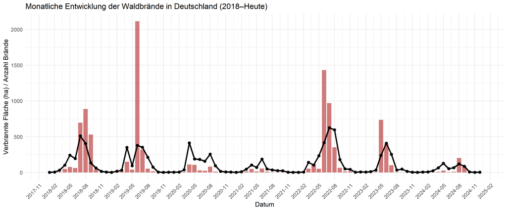

- In der Grafik sieht man, dass die Anzahl der Brände vor allem im Frühjahr und Sommer ansteigt, besonders zwischen April und August. Die verbrannte Fläche ist dagegen meist nur in einzelnen Monaten sehr hoch, häufig in besonders trockenen Sommermonaten. Das zeigt, dass große Flächenverluste nicht regelmäßig, sondern eher punktuell auftreten.
- Man erkennt deutlich, dass die höchsten Werte der Brandanzahl und der verbrannten Fläche nicht immer gleichzeitig auftreten. Während es mehrere Monate mit vielen Bränden gibt, zeigen die Balken für die verbrannte Fläche oft nur wenige starke Ausschläge. Das bedeutet, dass viele Brände eher klein bleiben, während einzelne große Brände für einen Großteil der Schadfläche verantwortlich sind.
- Die Grafik deutet darauf hin, dass viele Brände schnell entdeckt und gelöscht werden, weil sie meist durch alltägliche menschliche Aktivitäten entstehen. Solche Brände verursachen nur kleine Schäden. Große Brände entstehen dagegen oft unter schwierigeren Bedingungen wie Trockenheit, starkem Wind oder wenig Zugänglichkeit, sodass sie sich schneller ausbreiten können.
- Die Schwankungen hängen stark mit den Wetterbedingungen der jeweiligen Jahre zusammen. Heiße und trockene Sommer führen zu mehr und größeren Bränden, während feuchtere Sommer weniger Schäden verursachen. Auch menschliche Aktivitäten in den Sommermonaten sowie Unterschiede in Vegetation und Bodenfeuchte spielen eine wichtige Rolle.

## Unterschiede in Ost- und Westdeutschland

Nachdem Sie die Waldbranddynamik auf nationaler Ebene sowohl jährlich als auch saisonal analysiert haben, sollen Sie nun in die regionale Ebene einblicken. Eine deutschlandweite Betrachtung kann lokale Besonderheiten überdecken, die für gezielte politische Maßnahmen entscheidend sind. Um die strukturellen Unterschiede innerhalb Deutschlands besser zu verstehen, führen Sie eine vergleichende Analyse durch und konzentrieren sich auf zwei Bundesländer, die in den letzten Jahren besonders stark von Waldbränden betroffen waren, aber sehr unterschiedliche geografische und ökonomische Rahmenbedingungen aufweisen: Brandenburg im Osten und Bayern im Westen. Brandenburg, mit seinen sandigen Böden und ausgedehnten Kiefernwäldern, gilt als eine der trockensten und brandanfälligsten Regionen Deutschlands. Bayern hingegen ist durch seine Voralpenlage, Mischwälder und eine andere Wirtschaftsstruktur geprägt. Dieser Vergleich ermöglicht es zu untersuchen, ob es systematische Unterschiede im Schadensausmaß und in den wirtschaftlichen Verlusten zwischen Ost- und Westdeutschland gibt.

16. Erstellen Sie eine deskriptive Tabelle für die Jahre 2022 und 2023, die für Bayern und Brandenburg folgende Kennzahlen darstellt:
- Gesamtzahl der Brände
- Gesamtfläche der Brände (ha)
- Durchschnittliche Fläche pro Brand (ha/Brand)
- Gesamte wirtschaftliche Verluste (in Tsd. €)
- Verlust pro Hektar (in €/ha)

Beschreiben und interpretieren Sie ihre Tabelle und gehen insbesondere auf folgende Aspekte vertieft ein:

- Welches der beiden Bundesländer verzeichnet absolut gesehen mehr Brände und größere Flächenverluste?
- Welches Bundesland hat die höheren ökonomischen Verluste pro Hektar?
- Was könnte dieser Unterschied über den Wert und die Art der Wälder (z.B. Nutzwald vs. Schutzwald, Holzpreise) in den beiden Regionen aussagen?
- Basierend auf diesen Zahlen, würden Sie argumentieren, dass das “Waldbrandproblem” in beiden Bundesländern gleich gravierend ist, oder manifestiert es sich auf unterschiedliche Weise (z.B. häufige, aber weniger wertvolle Flächenbrände vs. seltenere, aber teurere Schäden)?

Kennzahlen zu Waldbränden in Bayern und Brandenburg (2022–2023)

| Region | Jahr | Gesamt Brände | Gesamtfläche (ha) | Ø Fläche pro Brand (ha) | Wirtschaftliche Verluste (Tsd. €) | Verlust pro Hektar (€/ha) |
| --- | --- | --- | --- | --- | --- | --- |
| Bayern | 2022 | 145 | 214 | 1.48 | 297.1 | 1388.1 |
| Bayern | 2023 | 75 | 44 | 0.59 | 197.6 | 4491.8 |
| Brandenburg | 2022 | 523 | 1426 | 2.73 | 13.6 | 9.5 |
| Brandenburg | 2023 | 251 | 765 | 3.05 | 6.9 | 9.0 |

- Brandenburg verzeichnet 2022 und 2023 sowohl deutlich mehr Brände als auch eine viel größere betroffene Fläche als Bayern. Das zeigt eine wesentlich stärkere Flächenbelastung in Brandenburg.
- Der Verlust pro Hektar ist in Bayern um ein Vielfaches höher. 2023 liegt er sogar bei über 4.000 €/ha, während Brandenburg bei nur rund 9 €/ha liegt. Das weist darauf hin, dass die bayerischen Wälder wirtschaftlich deutlich wertvoller sind.
- Die Unterschiede deuten darauf hin, dass Brandenburg stärker von großflächigen, aber ökonomisch weniger wertvollen Kiefernwäldern geprägt ist, während in Bayern eher wertintensive Waldbestände (z. B. Mischwälder, Schutzwälder) betroffen sind, wodurch einzelne Brandereignisse wesentlich teurer werden.
- Brandenburg hat ein Häufigkeitsproblem (viele Brände, große Flächen, geringe Kosten pro ha). Bayern hat ein Intensitätsproblem (wenige Brände, kleine Flächen, aber sehr hohe Kosten pro ha). Das Waldbrandproblem ist also in beiden Ländern gravierend, aber es äußert sich in völlig unterschiedlicher Form.

Die folgende Analyse schlüsselt die Verluste für die Jahre 2022 und 2023 für Bayern und Brandenburg weiter auf. Hier sollen Sie betrachten, wie groß die Verluste an hochpreisigem Stammholz und an günstigerem Industrieholz sind.

17. Erstellen Sie für die Jahre 2022 und 2023 ein Balkendiagramm, das die strukturellen Unterschiede der Waldbrandschäden in Bayern und Brandenburg visualisiert. Hierbei soll der absolute Verlust von Stammholz (in Festmetern, m³) und Industrieholz (in Festmetern, m³) für beide Bundesländer und beide Jahre vergleichend dargestellt werden.

Beschreiben und interpretieren Sie das Diagramm und gehen Sie dabei insbesondere auf folgende Aspekte ein:

- Vergleichen Sie die Entwicklung von 2022 zu 2023 in ihrem Diagramm. Welche Trends oder signifikanten Veränderungen fallen Ihnen auf?
- Welche ökonomischen Schlussfolgerungen lassen sich aus ihren Ergebnissen über die Art der geschädigten Wälder in den beiden Bundesländern ziehen?

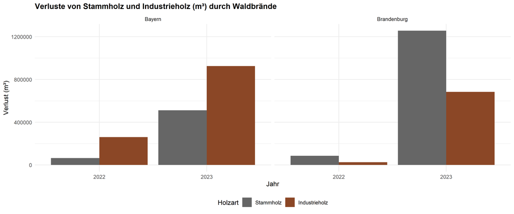

- In beiden Bundesländern steigen die Holzverluste von 2022 auf 2023 deutlich an. Besonders auffällig ist, dass Bayern 2023 sehr hohe Industrieholzverluste aufweist, während Brandenburg im gleichen Jahr extrem hohe Stammholzverluste zeigt. Insgesamt zeigt die Grafik, dass 2023 in beiden Regionen ein deutlich schadensreicheres Jahr war, aber mit unterschiedlichen Schwerpunkten.
- Die Unterschiede zwischen Stammholz- und Industrieholzmengen deuten auf unterschiedliche Waldstrukturen hin. In Bayern sind die Verluste 2023 stark industrieholzlastig, was für viele jüngere Bestände oder geringere Holzqualitäten spricht. Brandenburg verliert dagegen große Mengen an Stammholz, was auf höherwertige, ältere Bestände schließen lässt, die bei Bränden stärker betroffen sind. Ökonomisch bedeutet das: Beide Regionen erleiden hohe Schäden, aber in Brandenburg sind diese durch den höheren Anteil an Stammholz potenziell wertvoller.

Nachdem Sie in den vorherigen Aufgaben die Entwicklung der Waldbrände in Deutschland über die Jahre hinweg analysiert haben, zunächst auf Jahres- und dann auf Monatsebene, sowie getrennt nach Ost- und Westdeutschland, sollen Sie nun die ökonomische Wirksamkeit möglicher Gegenmaßnahmen bewerten.

18. Die Politik diskutiert verschiedene Ansätze, um das wachsende Problem der Waldbrände zu adressieren. Analysieren und bewerten Sie die folgenden drei Strategien unter dem Gesichtspunkt von Kosten und Nutzen. Argumentieren Sie, warum diese Maßnahmen sinnvoll oder weniger sinnvoll sein könnten und in welcher Form sie umgesetzt werden könnten:
1. “Abschreckung und Strafen: Eine signifikante Erhöhung der Bußgelder und Strafen für fahrlässige Brandstiftung (z.B. weggeworfene Zigaretten) und vorsätzliche Brandlegung.”
2. “Anreize für Waldumbau: Staatliche Subventionen und Förderprogramme für private und kommunale Waldbesitzer, um den Umbau von anfälligen Monokulturen (z.B. Kiefernwälder) in klimaresilientere und weniger brennbare Mischwälder zu beschleunigen.”
3. “Investition in Technologie: Ein flächendeckender Ausbau der technischen Überwachung durch moderne Systeme wie Drohnen mit Wärmebildkameras, Satellitenüberwachung und ein dichtes Netz an Sensoren zur Früherkennung.”

*Hinweis:* Beziehen Sie sich auf die vorherigen Aufgaben. Diskutieren Sie auch, welche Maßnahmen zu den beobachteten Schadensmustern, saisonalen Schwankungen und regionalen Unterschieden zwischen Ost- und Westdeutschland passen, und bedenken Sie Kosten-Nutzen-Aspekte.

1.) – Abschreckung und Strafen: Die Erhöhung von Strafen und Bußgeldern kann sinnvoll sein, weil viele Waldbrände in Deutschland nachweislich auf menschliches Fehlverhalten zurückgehen und dadurch theoretisch leicht vermeidbar wären. Eine stärkere Abschreckung kann insbesondere die große Zahl kleiner Brände reduzieren, die häufig auftreten und Einsatzkräfte belasten, auch wenn sie oft nur geringe Flächen betreffen. Gleichzeitig stößt diese Strategie an Grenzen, da sie kaum Einfluss auf Brände hat, die durch Wetterextreme, Trockenheit oder schwer kontrollierbare Faktoren entstehen. Umgesetzt werden könnte diese Maßnahme durch anpassbare Waldbrandverordnungen, gezielte Informationskampagnen und verstärkte Kontrollen in Hochrisikomonaten, wodurch die Wahrscheinlichkeit menschlicher Zündquellen messbar verringert werden könnte.

2.) - Anreize für Waldumbau: Der Waldumbau hin zu klimaresilienten, weniger brennbaren Mischwäldern gilt als langfristig sehr wirksame Maßnahme, weil die vorherigen Analysen gezeigt haben, dass bestimmte Waldstrukturen – besonders Monokulturen – deutlich anfälliger für schnelle Brandentwicklung und hohe wirtschaftliche Verluste sind. Diese Strategie reduziert sowohl die Brandhäufigkeit als auch die Intensität künftiger Brände, da Mischbaumarten besser mit Trockenheit umgehen und sich weniger leicht entzünden. Der Nachteil liegt in den hohen Kosten und der Tatsache, dass die Wirkung erst über Jahrzehnte sichtbar wird. Sinnvoll umgesetzt werden könnte der Waldumbau durch staatliche Förderprogramme, langfristige Beratungsangebote und finanzielle Unterstützung für Waldbesitzer, sodass eine strukturelle Risikoreduktion über Jahre hinweg aufgebaut wird.

3.) -Investition in Technologie: Moderne Überwachungstechnologien wie Drohnen, Satelliten oder Sensornetze können unmittelbar dazu beitragen, Waldbrände frühzeitig zu erkennen und damit große Schäden zu verhindern, da die vorherigen Auswertungen gezeigt haben, wie schnell sich Brände in trockenen Monaten ausbreiten können. Diese Systeme ermöglichen ein schnelleres Eingreifen, bevor Brände auf große Flächen übergreifen, und sind deshalb besonders wirksam, um hohe wirtschaftliche Verluste zu vermeiden. Allerdings erfordert diese Strategie hohe Anfangsinvestitionen und eine verlässliche technische Infrastruktur, und sie verhindert Brände nicht vollständig, sondern reduziert hauptsächlich deren Ausmaß. Eine Umsetzung wäre über regionale oder bundesweit koordinierte Überwachungssysteme möglich, die automatisierte Alarmierung mit Einsatzplanung verbinden und so eine schnelle Reaktionskette sicherstellen.

# Zusatzfrage (optional)

Diese Frage ist von der Bearbeitung her etwas schwieriger. Bevor Sie sich an diese Aufgabe machen, sollten Sie sicherstellen, dass Sie alle vorherigen Fragen ausführlich beantwortet haben. Eine korrekte Beantwortung dieser Frage gibt einen Punktebonus von 3 Punkten (das Projekt umfasst insgesamt 30 Punkte, inkl. Screencast).

In den vorangegangenen Aufgaben haben Sie eine umfassende Analyse der ökonomischen Rahmenbedingungen der Land- und Forstwirtschaft in Deutschland durchgeführt. Sie betrachteten dabei sowohl die direkten Kosten und Förderungen auf nationaler Ebene als auch spezifische Treiber von Waldbrandschäden. Anschließend haben Sie den Fokus auf regionale Unterschiede verengt und gezeigt, dass beispielsweise in Bayern und Brandenburg die Dynamik von Waldbränden deutlich variiert. Ein Hinweis darauf, dass sowohl ökologische als auch ökonomische Faktoren lokal sehr unterschiedlich wirken.

Im nächsten Schritt weiten Sie den Blick nun auf die EU-Ebene. Sie analysieren die Verteilung und Entwicklung der Agrar- und Forstwirtschaftssubventionen über verschiedene Länder hinweg. Ziel ist es, die Gesamtbeträge pro Land und Jahr zu betrachten, Unterschiede zwischen den Mitgliedsstaaten zu identifizieren und ein Verständnis dafür zu entwickeln, wie Förderungen innerhalb Europas verteilt sind und sich über die Jahre verändern.

19. Lesen Sie den Datensatz `Finanzsubventionen_EU.csv` ein und speichern Sie diesen als `eu_subventionen` ab. Filtern Sie nur für die Jahre ab 2010 und behalten Sie ausschließlich Länder (keine aggregierten EU-Werte). Verschaffen Sie sich nun einen ersten Überblick über ihren Datensatz. Beantworten Sie hierzu folgende Fragen:
- Welche Länder sind im Datensatz konkret enthalten?
- Über welchen Zeitraum erstreckt sich der Datensatz?
- Sie haben die Spalte `Indicator_Type`. Recherchieren und erklären Sie die Bedeutung der darin enthaltenen Typen `Output_Pillar I` und `Output_Pillar II`.
- Warum gibt es bei `Output_Pillar I` die Kategorien Direct Payments und Market Measures und bei `Output_Pillar II` Rural Development.
- Inwiefern sind die Indikatorentypen (`Indicator_Type`) mit den verschiedenen Förderarten in Deutschland vergleichbar.

Berechnen Sie nun mit dem Datensatz `eu_subventionen` die Gesamtsubventionen pro Land und Jahr. Gruppieren Sie hierzu nach `Member_Name` (Land) und `Time` (Jahr). Summieren Sie anschließend die Subventionen (Subsidy) pro Land und Jahr zu `Total_Subsidy` und achten Sie darauf, fehlende Werte korrekt zu behandeln. Speichern Sie dies wiederum in `eu_subventionen` ab.

*Hinweis:* Den Datensatz hierfür haben wir für Sie wieder vorbereitet. Die Ursprungsdaten können [hier](https://agridata.ec.europa.eu/extensions/DashboardIndicators/Financing.html) eingesehen werden.

Nachdem Sie in der vorherigen Aufgabe die Gesamtsubventionen pro Land und Jahr berechnet haben, sollen Sie nun den Datensatz vorbereiten, um im weiteren Verlauf die Verteilung der Subventionen über Europa anschaulich darzustellen. Ziel ist es, die Unterschiede zwischen Ländern und die Entwicklung über die Jahre interaktiv zu visualisieren. Hierfür können Sie im weiteren Verlauf Plotly nutzen, um eine dynamische Karte zu erstellen, die sich manuell über die Jahre steuern lässt.

20. Um die Daten für die Visualisierung aufzubereiten und interaktiv darzustellen, laden Sie die folgenden Libraries:
- `library(rnaturalearth)`
- `library(rnaturalearthdata)`
- `library(plotly)`

Mit `rnaturalearth` erhalten Sie die geometrischen Daten der Länder für die Kartendarstellung. Speichern Sie in `europe` wiefolgt die geometrischen Daten ab:

- `europe <- ne_countries(scale = "medium",continent = "Europe", returnclass = "sf")`

Erstellen Sie nun den Datensatz `plot_subventionen`, indem Sie die geometrischen Daten mit den aggregierten Subventionsdaten verbinden. Selektieren Sie hierfür die Variablen `name`, `iso_a3` und `geometry` aus dem world-Datensatz, joinen Sie dann den `eu_subventionen`-Datensatz über `name` bzw. `Member_Name` und filtern Sie auf die Daten zu denen Sie Subventionswerte haben.

Bevor Sie zu der interaktiven Visualisierung der Subventionen über Länder und Jahre übergehen, sollen Sie sich einen ersten Überblick über die Subventionen in der Vergangenheit verschaffen. Sie haben sich im bisherigen Projekt bereits ausführlich mit den Subventionszahlungen in Deutschland für 2023 und 2024 beschäftigt. Um zu sehen, in welchem Kontext Deutschland in der Vergangenheit stand, sollen Sie nun die 10 größten Länder nach Subventionszahlungen zwischen 2020 und 2022 darstellen und vergleichen.

21. Erstellen Sie für die Jahre 2020 bis 2022 eine oder mehrere geeignete Grafik(en), die die Subventionszahlungen der EU in den größten Empfängerländern veranschaulichen. Hierbei soll einerseits die absolute Höhe der Gesamtsubventionen für die Top 10 Länder über die drei Jahre vergleichend dargestellt werden. Weiterhin sollen die Subventionen gestapelt nach Jahr aufgeschlüsselt werden, sodass die Entwicklung der Zahlungen pro Land über die Jahre 2020, 2021 und 2022 sichtbar wird. Filtern Sie hierzu den Datensatz `plot_subventionen` auf die Jahre 2020 bis 2022. Rechnen Sie die Subventionswerte geeignet um, damit sie lesbar dargestellt werden können.

Beschreiben und interpretieren Sie die Grafik(en) und gehen Sie dabei insbesondere auf folgende Aspekte ein:

- Vergleichen Sie die Entwicklung der Subventionen für die Top 10 Länder zwischen 2020, 2021 und 2022. Welche Trends fallen Ihnen auf?
- Gibt es Länder, bei denen die Subventionen während der 3 Jahre gestiegen oder gefallen sind? Welche möglichen Gründe könnten dies erklären?
- Welche Länder erhalten vergleichsweise geringere Förderungen, und wie lässt sich dies im europäischen Kontext einordnen?
- Was sind mögliche Ursachen für diese Verteilung? Recherchieren Sie mögliche Gründe, die auf die Landwirtschaft, erwirtschafteten Erträge und Entwicklung zurückzuführen sind.

*Hinweis:* Bestimmen Sie die Top 10 Länder nach Gesamtsumme über die drei Jahre.

[figure not shown]

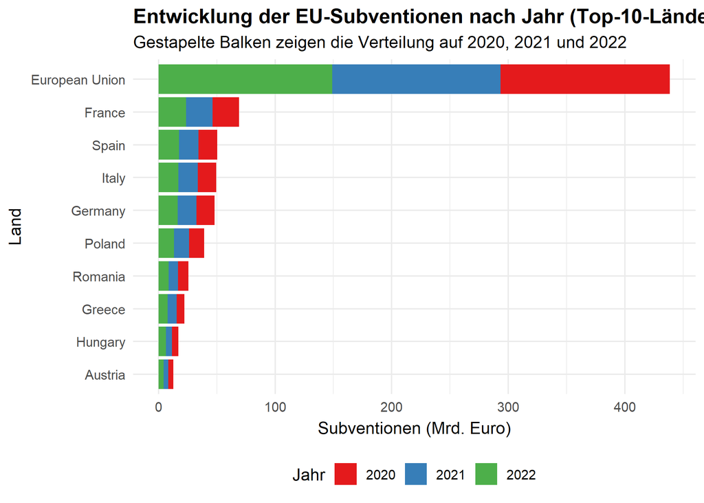

Wie Sie eben schon bemerken konnten, wird ein gestapeltes Balkendiagramm bei vielen Ländern und über mehrere Jahre hinweg schnell unübersichtlich. Um dem entgegenzuwirken, sollen Sie eine andere Form der Visualisierung anwenden. Sie werden sich die Verteilung der Subventionen über alle EU-Länder im Datensatz und für die Jahre 2010 bis 2022 anschauen und diese interaktiv visualisieren. Ziel ist es, dass Sie Trends, Unterschiede und Ausreißer bei den Subventionszahlungen zwischen den Ländern erkennen und über die Zeit nachvollziehen können.

22. Erstellen Sie eine interaktive Karte. Nutzen Sie hierfür den Datensatz `plot_subventionen`, der die Länder-Geometrien (`geometry`), die aggregierten Subventionen (`Total_Subsidy`) und die Länderkennungen (`iso_a3`) enthält. Verwenden Sie die Funktion `plot_ly()`. Visualisieren Sie die Subventionen pro Land und Jahr, sodass die Karte über die Jahre animiert bzw. per Slider steuerbar ist. Gestalten Sie die Farbskala und den Text so, dass Subventionen und Länder leicht ablesbar sind. Optimieren Sie die Karte, um die Darstellung übersichtlich zu machen. Beschreiben und interpretieren Sie die interaktive Grafik, insbesondere hinsichtlich folgender Aspekte:
- Welche Länder erhalten die geringsten Subventionssummen, und wie entwickelt sich dies über die Jahre 2010-2022?
- Gibt es Länder, bei denen die Subventionen stark gestiegen oder gefallen sind? Welche möglichen Ursachen könnten dies haben?
- Woran liegt es, dass gewisse Länder keine Einfärbung erhalten?
- Wie könnten sich hohe Subventionen für einzelne Länder auf den Wettbewerb innerhalb der EU und die Struktur der Landwirtschaft auswirken?
- Welche Schlussfolgerungen lassen sich ziehen, wenn Länder mit stark schwankenden Subventionen zu erkennen sind? Könnte dies auf politische Entscheidungen, wirtschaftliche Krisen oder andere Faktoren hinweisen?

*Hinweis:* Überprüfen Sie die ISO3-Codes: Wenn einzelne Länder nicht korrekt angezeigt werden, können Sie die Codes in der Spalte iso_a3 anpassen.

Abschließend sollen Sie die Zusatzaufgabe noch einmal rekapitulieren und einige Fragen dazu beantworten.

23. Sie sollen sich noch einmal bewusst werden, was Sie in den vorherigen Aufgaben analysiert haben und in welcher Form ihre Ergebnisse anwendbar und verallgemeinerbar sind. Beantworten Sie dazu Frage 1 und 2.

Frage 1: Betrachten Sie exemplarisch Deutschland und Frankreich in Ihrer interaktiven Karte.

- Lassen sich Unterschiede in den Subventionssummen zwischen den beiden Ländern vor allem durch politische Rahmenbedingungen, agrarische Strukturen oder durch EU-weite Fördermaßnahmen erklären?
- Welche Schlussfolgerungen könnten daraus für die wirtschaftspolitische Steuerung oder für die Vergleichbarkeit der Subventionen zwischen Ländern gezogen werden?

Frage 2: Vergleichen Sie Länder mit stark schwankenden Subventionen über die Jahre (z.B. Länder, bei denen es große Anstiege oder Rückgänge gibt).

- Was fällt Ihnen bei der Verteilung und der zeitlichen Entwicklung der Subventionen auf?
- Recherchieren Sie für diese Länder mögliche Ursachen, die diese Schwankungen verursacht haben könnten (z.B. politische Entscheidungen, Fördermaßnahmen, wirtschaftliche Krisen, Struktur der Landwirtschaft)?